# Implied Volatilities

Here, I am looking again at the Black-Scholes-Merton model and options pricing. The example comes from the book [Python for Finance](https://www.amazon.com/Python-Finance-Analyze-Financial-Data/dp/1491945281) by Yves Hilpisch. The example following discussion of the Black-Scholes-Merton model will cover volatility options on the VSTOXX volatility index.

$$C(S_t,K,t,T,r,\sigma ) = S_t\cdot \boldsymbol{N}(d_1)-e^{-r(T-t)}\cdot K\cdot \boldsymbol{N}(d_2)$$$$\boldsymbol{N}(d)=\frac{1}{\sqrt{2\pi}}\int_{-\infty}^{d}e^{-\frac{1}{2}x^2}dx$$$$d_1=\frac{log\frac{S_t}{K}+\left ( r+\frac{\sigma^2}{2} \right )}{\sigma\sqrt{T-t}}(T-t)$$$$d_2=\frac{log\frac{S_t}{K}+\left ( r-\frac{\sigma^2}{2} \right )}{\sigma\sqrt{T-t}}(T-t)$$

The parameters have the following meaning:

$S_t$ = Price/level of the underlying at time t

$\sigma$ = Constant volatility (i.e., standard deviation of returns) of the underlying

$K$ = Strike price of the option

$T$ = Maturity date of the option

$r$ Constant riskless short rate

Consider now that an option quote for a European call option $C^*$ is given. The implied volatility $\sigma^{imp} is the quantity that solves the implicit equation below.

Implied volatility given market quote for option $$C\!\left(S_t,K,t,T,r,\sigma^{imp}\right )=C^{*}$$

Newton's Method for numerically solving equations

$$\sigma^{imp}_{n+1}=\sigma^{imp}_n-\frac{C(\sigma^{imp}_n)-C^{*}}{\partial C(\sigma^{imp}_n)/\partial \sigma^{imp}_n}$$

The partial derivative of the option pricing formula with respect to the volatiity is called **Vega** and is given below:

$$\frac{\partial}{\partial\sigma}=S_t\:\boldsymbol{N}(d_1)\sqrt{T-t}$$

While we are at it, let's review Newtons Method. This is a very cool way to look at roots.

The general idea is as follows:

$$x_{n+1}=x_n-\frac{f(x_n)}{f^{'}\!(x_n)}$$

Say we have the following function $f(x)=x^3-10x+2$ and we guess a root $x_0=10$. First we need the derivative of $f(x)$ which is $f'(x)=3x^2-10$.

To get to $x_1$ we need to plug our guess into the equation.

For $x_0=10$ we have:

$$x_{n+1}=x_0-\frac{x_0^3-10x_0+2}{3x_0^2-10}$$

or

$$x_{1}\approx6.889655\approx10-\frac{902}{290}$$$$x_{2}\approx4.924904\approx6.889655-\frac{260.1371}{132.402}$$$$x_{3}\approx3.774517\approx4.924904-\frac{72.20291}{62.76403}$$

Now we have to tools necesary to look at the Python code that assumes **the special case where $t=0$**.

1) $$C(S_t,K,t,T,r,\sigma ) = S_t\cdot \boldsymbol{N}(d_1)-e^{-r(T-t)}\cdot K\cdot \boldsymbol{N}(d_2)$$

2) $$\boldsymbol{N}(d)=\frac{1}{\sqrt{2\pi}}\int_{-\infty}^{d}e^{-\frac{1}{2}x^2}dx$$

3) $$d_1=\frac{log\frac{S_t}{K}+\left ( r+\frac{\sigma^2}{2} \right )}{\sigma\sqrt{T-t}}(T-t)$$

4) $$d_2=\frac{log\frac{S_t}{K}+\left ( r-\frac{\sigma^2}{2} \right )}{\sigma\sqrt{T-t}}(T-t)$$

```python
#from math import log, sqrt, exp
#from scipy import stats
```

```python
#
# Valuation of European call options in Black-Scholes-Merton model
# incl. Vega function and implied volatility estimation
# bsm_functions.py
#

# Analytical Black-Scholes-Merton (BSM) Formula

def bsm_call_value(S0, K, T, r, sigma):
    '''
    Valuation of European call option in BSM model.
    Analytical formula

    Parameters
    ==========
    S0 : float
        inital stock/index level
    K : float
        strike price
    T : float
        maturity date (in year fractions)
    r : float
        constant risk-free short rate
    sigma : float
        volatility factor in diffusion term


    Returns
    =======
    value : float
        present value of the European call option
    '''
    from math import log, sqrt, exp
    from scipy import stats

    S0 = float(S0)
    #3)
    d1 = (log(S0 / K)+ (r + 0.5 * sigma ** 2) * T) / (sigma * sqrt(T))
    #4)
    d2 = (log(S0 / K)+ (r - 0.5 * sigma ** 2) * T) / (sigma * sqrt(T))
    # Page for norm.cdf
    # http://docs.scipy.org/doc/scipy/reference/generated/scipy.stats.norm.html#scipy.stats.norm
    #1,2)
    value = (S0 * stats.norm.cdf(d1, 0.0, 1.0) - K * exp(-r * T) *
             stats.norm.cdf(d2, 0.0, 1.0))
      # stats.norm.cdf --> cumulative distribution function for
      #                    normal distribution
    return value
```

```python
# Vega function

def bsm_vega(S0, K, T, r, sigma):
    '''
    Vega of European option in BSM model.

    Parameters
    ==========
    S0 : float
        initial stock/index level
    K : float
        strike price
    T : float
        maturity date (in yar fractions)
    r : float
        constant risk-free short rate
    sigma : float
        volatility factor in diffusion term

    Returns
    =======
    vega : float
        partial derivative of BSM formula with respect to sigma, i.e, Vega

    '''
    from math import log, sqrt
    from scipy import stats

    S0 = float(S0)
    d1 = (log(S0 / K ) + (r + 0.5 * sigma ** 2) * T) / (sigma * sqrt(T))
    vega = S0 * stats.norm.cdf(d1, 0.0, 1.0) * sqrt(T)
    return vega
```

```python
# Implied volatility function

def bsm_call_imp_vol(S0, K, T, r, C0, sigma_est, it=100):
    '''
    Implied volatility of European call option in BSM model.

    Parameters
    ==========
    S0 : float
        initial stock/index level
    K : float
        strike price
    T : float
        maturity date (in year fractions)
    r : float
        constant risk-free short rate
    sigma_est : float
        estimate of implied volatility
    it : integer
        number of iterations

    Returns
    =======
    sigma_est : float
        numerically estimated implied volatility
    '''
    for i in range(it):
        sigma_est -= ((bsm_call_value(S0, K, T, r, sigma_est) - C0
                      )
                      / bsm_vega(S0, K, T, r, sigma_est))
    return sigma_est
```

Now, we need to get option quotes. In this case, we are looking for [European call](http://www.call-options.com/european-call-option.html) options.

```python
V0 = 17.639
```

For the risk-free short rate, we assume a value of $r=0.01$:

```python
r = 0.01
```

Everything else is given by the options data (i.e, T and K) or have to be determined (i.e., $\sigma^{imp}$). The data is stored in a pandas DataFrame object and saved in a PyTables database file.

```python
import pandas as pd
h5=pd.HDFStore('/home/fdrennan/Documents/Data/vstoxx_data_31032014.h5', 'r')
futures_data = h5['futures_data'] # VSTOXX futures data
options_data = h5['options_data'] # VSTOXX call option data
h5.close()

# Make Dates Readable
futures_data['DATE'] = pd.to_datetime(futures_data['DATE'])
futures_data['MATURITY'] = pd.to_datetime(futures_data['MATURITY'])
```

We need the futures data to select a subset of the VSTOXX options given their (forward) moneyness. Eight futures on the VSTOXX are traded at any time. Their maturities are the next eight *third Fridays* of the month. At the end of March, there are futures with maturities ranging from the third Friday of April to the third Friday of November. TTM in the following pandas table represents time-to-maturity in year fractions:

```python
futures_data
```

|  | DATE | EXP_YEAR | EXP_MONTH | PRICE | MATURITY | TTM |
| --- | --- | --- | --- | --- | --- | --- |
| 496 | 2014-03-31 | 2014 | 4 | 17.85 | 2014-04-18 | 0.049 |
| 497 | 2014-03-31 | 2014 | 5 | 19.55 | 2014-05-16 | 0.126 |
| 498 | 2014-03-31 | 2014 | 6 | 19.95 | 2014-06-20 | 0.222 |
| 499 | 2014-03-31 | 2014 | 7 | 20.40 | 2014-07-18 | 0.299 |
| 500 | 2014-03-31 | 2014 | 8 | 20.70 | 2014-08-15 | 0.375 |
| 501 | 2014-03-31 | 2014 | 9 | 20.95 | 2014-09-19 | 0.471 |
| 502 | 2014-03-31 | 2014 | 10 | 21.05 | 2014-10-17 | 0.548 |
| 503 | 2014-03-31 | 2014 | 11 | 21.25 | 2014-11-21 | 0.644 |

The options dataset is larger since at any given trading day multiple call and put options are traded per maturity date. The maturyity dates, however are the same as for the futures. There are a total of 395 call options quoted on March 31, 2014:

```python
options_data['DATE'] = pd.to_datetime(options_data['DATE'])
options_data['MATURITY'] = pd.to_datetime(options_data['MATURITY'])
options_data.info()
options_data[['DATE', 'MATURITY', 'TTM', 'STRIKE', 'PRICE']]
```

```
<class 'pandas.core.frame.DataFrame'>
Int64Index: 395 entries, 46170 to 46564
Data columns (total 8 columns):
DATE         395 non-null datetime64[ns]
EXP_YEAR     395 non-null int64
EXP_MONTH    395 non-null int64
TYPE         395 non-null object
STRIKE       395 non-null float64
PRICE        395 non-null float64
MATURITY     395 non-null datetime64[ns]
TTM          395 non-null float64
dtypes: datetime64[ns](2), float64(3), int64(2), object(1)
memory usage: 27.8+ KB
```

|  | DATE | MATURITY | TTM | STRIKE | PRICE |
| --- | --- | --- | --- | --- | --- |
| 46170 | 2014-03-31 | 2014-04-18 | 0.049 | 1.0 | 16.85 |
| 46171 | 2014-03-31 | 2014-04-18 | 0.049 | 2.0 | 15.85 |
| 46172 | 2014-03-31 | 2014-04-18 | 0.049 | 3.0 | 14.85 |
| 46173 | 2014-03-31 | 2014-04-18 | 0.049 | 4.0 | 13.85 |
| 46174 | 2014-03-31 | 2014-04-18 | 0.049 | 5.0 | 12.85 |
| 46175 | 2014-03-31 | 2014-04-18 | 0.049 | 6.0 | 11.85 |
| 46176 | 2014-03-31 | 2014-04-18 | 0.049 | 7.0 | 10.85 |
| 46177 | 2014-03-31 | 2014-04-18 | 0.049 | 8.0 | 9.85 |
| 46178 | 2014-03-31 | 2014-04-18 | 0.049 | 9.0 | 8.85 |
| 46179 | 2014-03-31 | 2014-04-18 | 0.049 | 10.0 | 7.85 |
| 46180 | 2014-03-31 | 2014-04-18 | 0.049 | 11.0 | 6.85 |
| 46181 | 2014-03-31 | 2014-04-18 | 0.049 | 12.0 | 5.85 |
| 46182 | 2014-03-31 | 2014-04-18 | 0.049 | 13.0 | 4.85 |
| 46183 | 2014-03-31 | 2014-04-18 | 0.049 | 14.0 | 3.85 |
| 46184 | 2014-03-31 | 2014-04-18 | 0.049 | 15.0 | 2.90 |
| 46185 | 2014-03-31 | 2014-04-18 | 0.049 | 16.0 | 2.00 |
| 46186 | 2014-03-31 | 2014-04-18 | 0.049 | 17.0 | 1.35 |
| 46187 | 2014-03-31 | 2014-04-18 | 0.049 | 18.0 | 0.95 |
| 46188 | 2014-03-31 | 2014-04-18 | 0.049 | 19.0 | 0.70 |
| 46189 | 2014-03-31 | 2014-04-18 | 0.049 | 20.0 | 0.50 |
| 46190 | 2014-03-31 | 2014-04-18 | 0.049 | 21.0 | 0.40 |
| 46191 | 2014-03-31 | 2014-04-18 | 0.049 | 22.0 | 0.35 |
| 46192 | 2014-03-31 | 2014-04-18 | 0.049 | 23.0 | 0.25 |
| 46193 | 2014-03-31 | 2014-04-18 | 0.049 | 24.0 | 0.25 |
| 46194 | 2014-03-31 | 2014-04-18 | 0.049 | 25.0 | 0.20 |
| 46195 | 2014-03-31 | 2014-04-18 | 0.049 | 26.0 | 0.15 |
| 46196 | 2014-03-31 | 2014-04-18 | 0.049 | 27.0 | 0.15 |
| 46197 | 2014-03-31 | 2014-04-18 | 0.049 | 28.0 | 0.15 |
| 46198 | 2014-03-31 | 2014-04-18 | 0.049 | 29.0 | 0.10 |
| 46199 | 2014-03-31 | 2014-04-18 | 0.049 | 30.0 | 0.10 |
| ... | ... | ... | ... | ... | ... |
| 46535 | 2014-03-31 | 2014-11-21 | 0.644 | 20.0 | 3.70 |
| 46536 | 2014-03-31 | 2014-11-21 | 0.644 | 21.0 | 3.35 |
| 46537 | 2014-03-31 | 2014-11-21 | 0.644 | 22.0 | 3.05 |
| 46538 | 2014-03-31 | 2014-11-21 | 0.644 | 23.0 | 2.80 |
| 46539 | 2014-03-31 | 2014-11-21 | 0.644 | 24.0 | 2.60 |
| 46540 | 2014-03-31 | 2014-11-21 | 0.644 | 25.0 | 2.40 |
| 46541 | 2014-03-31 | 2014-11-21 | 0.644 | 26.0 | 2.20 |
| 46542 | 2014-03-31 | 2014-11-21 | 0.644 | 27.0 | 2.05 |
| 46543 | 2014-03-31 | 2014-11-21 | 0.644 | 28.0 | 1.95 |
| 46544 | 2014-03-31 | 2014-11-21 | 0.644 | 29.0 | 1.80 |
| 46545 | 2014-03-31 | 2014-11-21 | 0.644 | 30.0 | 1.70 |
| 46546 | 2014-03-31 | 2014-11-21 | 0.644 | 32.5 | 1.40 |
| 46547 | 2014-03-31 | 2014-11-21 | 0.644 | 35.0 | 1.20 |
| 46548 | 2014-03-31 | 2014-11-21 | 0.644 | 37.5 | 1.00 |
| 46549 | 2014-03-31 | 2014-11-21 | 0.644 | 40.0 | 0.85 |
| 46550 | 2014-03-31 | 2014-11-21 | 0.644 | 42.5 | 0.70 |
| 46551 | 2014-03-31 | 2014-11-21 | 0.644 | 45.0 | 0.60 |
| 46552 | 2014-03-31 | 2014-11-21 | 0.644 | 47.5 | 0.50 |
| 46553 | 2014-03-31 | 2014-11-21 | 0.644 | 50.0 | 0.40 |
| 46554 | 2014-03-31 | 2014-11-21 | 0.644 | 55.0 | 0.25 |
| 46555 | 2014-03-31 | 2014-11-21 | 0.644 | 60.0 | 0.20 |
| 46556 | 2014-03-31 | 2014-11-21 | 0.644 | 65.0 | 0.15 |
| 46557 | 2014-03-31 | 2014-11-21 | 0.644 | 70.0 | 0.10 |
| 46558 | 2014-03-31 | 2014-11-21 | 0.644 | 75.0 | 0.05 |
| 46559 | 2014-03-31 | 2014-11-21 | 0.644 | 80.0 | 0.05 |
| 46560 | 2014-03-31 | 2014-11-21 | 0.644 | 85.0 | 0.05 |
| 46561 | 2014-03-31 | 2014-11-21 | 0.644 | 90.0 | 0.05 |
| 46562 | 2014-03-31 | 2014-11-21 | 0.644 | 95.0 | 0.05 |
| 46563 | 2014-03-31 | 2014-11-21 | 0.644 | 100.0 | 0.05 |
| 46564 | 2014-03-31 | 2014-11-21 | 0.644 | 105.0 | 0.05 |

395 rows × 5 columns

There are options traded that are far in and out of the money in the DataFrame, therefore we want to restrict the analysis to those call options with a certain (forward) moneyness, given the value of the futures for the respective maturity. We allow maximum deviation of 50% from the futures level. Before we can start, we need to define a new column in the options_data DataFrame object to store the results. We also need to import the functions above if we were working with a separate sheet.

```python
options_data['IMP_VOL'] = 0.0
    # new column for implied volatilities
```

```python
# if the above functions were saved as bsm_functions.pythe
# from bsm_functions import *
futures_data["MATURITY"]
```

```
496   2014-04-18
497   2014-05-16
498   2014-06-20
499   2014-07-18
500   2014-08-15
501   2014-09-19
502   2014-10-17
503   2014-11-21
Name: MATURITY, dtype: datetime64[ns]
```

```python
tol = 0.5 # tolerance level for moneyness
for option in options_data.index:
    # iterating over all options quotes
    # forward = futures_data[futures_data['MATURITY'] == \
    forward = futures_data[futures_data['MATURITY'] ==
                          options_data.loc[option]['MATURITY']]['PRICE'].values[0]
    # picking the right futures value
    if (forward * (1 - tol) < options_data.loc[option]['STRIKE']
                               < forward * (1 + tol)):
        # only for options with moneyness within tolerance
        imp_vol = bsm_call_imp_vol(
                V0, # VSTOXX value
                options_data.loc[option]['STRIKE'],
                options_data.loc[option]['TTM'],
                r, # short rate
                options_data.loc[option]['PRICE'],
                sigma_est=2., # estimate for implied volatility
                it = 100)
        options_data['IMP_VOL'].loc[option] = imp_vol
```

The implied volatilities for the selected options shall now be visualized. To this end, we use only the subset of the options_data object for which we have calculated the implied volatility.

```python
plot_data = options_data[options_data['IMP_VOL'] > 0]
```

To visualize the data, we iterate over all maturities of the data set and plot the implied volatilities both as lines and as single points. Since all maturities appear multiple times, we need to use a little trick to get to a nonredndent, sorted list with the maturities. The set operation gets rid of duplicates, but might deliver an unsorted *set* of the maturities. Therefore, we sort the *set* object.

```python
maturities = sorted(set(options_data['MATURITY']))
```

```python
maturities
```

```
[Timestamp('2014-04-18 00:00:00'),
 Timestamp('2014-05-16 00:00:00'),
 Timestamp('2014-06-20 00:00:00'),
 Timestamp('2014-07-18 00:00:00'),
 Timestamp('2014-08-15 00:00:00'),
 Timestamp('2014-09-19 00:00:00'),
 Timestamp('2014-10-17 00:00:00'),
 Timestamp('2014-11-21 00:00:00')]
```

The following code iterates over all maturities and does the plotting. The result is shown as the figure below. As in stock or foreign exchange markets, you will notice the so-called *volatility smile*, which is most pronounced for the shortest maturity and which becomes a bit less pronounced for the longer maturities.

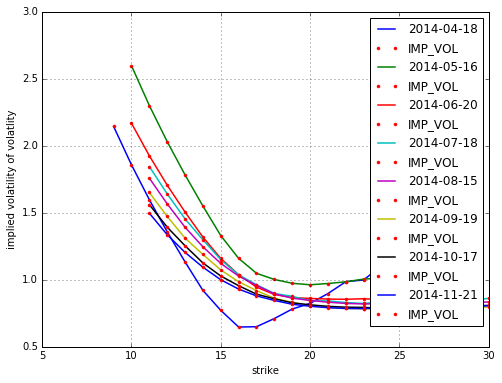

```python
import matplotlib.pyplot as plt
%matplotlib inline
plt.figure(figsize=(8,6))
for maturity in maturities:
    data = plot_data[options_data.MATURITY == maturity]
        # select data for this maturity
    plt.plot(data['STRIKE'], data['IMP_VOL'],
            label=maturity.date(), lw=1.5)
    plt.plot(data['STRIKE'], data['IMP_VOL'], 'r.')
plt.grid(True)
plt.xlabel('strike')
plt.ylabel('implied volatility of volatlity')
plt.legend()
plt.show()
```